# Beta Regression vs Kumaraswamy-Based Models for Bounded Data

Lopes, J. E.

2026-01-08

# 1 Abstract

Beta regression has become the standard approach for modeling continuous responses bounded in the unit interval. However, its reliance on the incomplete beta function for the cumulative distribution function (CDF) presents computational challenges, and the distribution may inadequately represent data with heavy tails or extreme concentrations near boundaries. This study presents a comprehensive comparison between traditional Beta regression and alternative approaches based on the Kumaraswamy distribution family, which offers analytical tractability through a closed-form CDF while maintaining comparable flexibility.

**Keywords:** Beta regression, Kumaraswamy distribution, bounded data, unit interval, computational efficiency

# 2 Introduction

## 2.1 Motivation and Background

Regression analysis for continuous responses restricted to the unit interval $(0,1)$ arises frequently across scientific disciplines. Applications include modeling proportions, rates, percentages, and other bounded measures in ecology, psychology, economics, and biostatistics (Ferrari & Cribari-Neto, 2004; Smithson & Verkuilen, 2006).

Beta regression, introduced systematically by Ferrari & Cribari-Neto (2004), has emerged as the predominant framework for such analyses. The Beta distribution’s flexibility in accommodating various shapes through its two-parameter family $(α, β)$ makes it attractive for modeling heterogeneous unit-interval data. However, several limitations warrant consideration:

1. **Computational burden**: The Beta distribution lacks a closed-form CDF, requiring numerical integration
2. **Boundary behavior**: May exhibit poor convergence for extreme J-shaped or U-shaped distributions
3. **Tail flexibility**: Limited capacity to accommodate distributions with heavier tails than the Beta family naturally supports

## 2.2 The Kumaraswamy Alternative

Kumaraswamy (1980) introduced a two-parameter distribution on $(0,1)$ that closely mimics Beta distribution properties while offering a **closed-form CDF**:

$$F(x; α, β) = 1 - (1-x^α)^β$$

This analytical tractability provides computational advantages while maintaining statistical flexibility comparable to the Beta distribution. Recent extensions have generalized the Kumaraswamy family to accommodate additional shape parameters, creating a hierarchical structure that nests both Beta and Kumaraswamy as special cases (Cordeiro & de Castro, 2011).

## 2.3 Study Objectives

This article addresses three research questions:

1. **Computational efficiency**: How do Kumaraswamy-based regression models compare to Beta regression in terms of estimation speed and convergence reliability?
2. **Statistical adequacy**: Under which data-generating mechanisms do Kumaraswamy models provide equivalent, superior, or inferior fit compared to Beta regression?
3. **Parameter estimation**: How do coefficient estimates and their standard errors differ across distributional families, and what are the practical implications?

We address these questions through rigorous Monte Carlo simulations comparing the `betareg` package (Cribari-Neto & Zeileis, 2010) with the `gkwreg` package, which implements regression models for the Kumaraswamy, Exponentiated Kumaraswamy, and Generalized Kumaraswamy distributions.

```r
library(gkwreg)
library(betareg)
library(ggplot2)

# Standardized color palette for all comparisons
MODEL_COLORS <- c(
  "Beta (betareg)" = "#D32F2F", # Red
  "Beta (gkwreg)" = "#1976D2", # Blue
  "Kumaraswamy" = "#388E3C", # Green
  "Exp. Kumaraswamy" = "#7B1FA2" # Purple
)

MODEL_NAMES <- c(
  betareg = "Beta (betareg)",
  gkw_beta = "Beta (gkwreg)",
  gkw_kw = "Kumaraswamy",
  gkw_ekw = "Exp. Kumaraswamy"
)
```

# 3 Theoretical Framework

## 3.1 Distributional Families

### 3.1.1 Beta Distribution

The Beta distribution with shape parameters $α, β > 0$ has probability density function:

$$f(x; α, β) =
\frac{x^{α-1}(1-x)^{β-1}}{B(α,β)}, \quad x \in (0,1)$$

where $B(α,β) = \int_0^1 t^{α-1}(1-t)^{β-1}dt$ is the beta function. Key properties include:

- **Mean**: $E[X] = α/(α+β)$
- **Variance**: $\text{Var}(X) = αβ/[(α+β)^2(α+β+1)]$
- **CDF**: No closed form; requires numerical integration

### 3.1.2 Kumaraswamy Distribution

The Kumaraswamy distribution (Kumaraswamy, 1980) with parameters $α, β > 0$ has PDF:

$$f(x; α, β) = αβx^{α-1}(1-x^α)^{β-1},
\quad x \in (0,1)$$

Distinguished by its **closed-form CDF**:

$$F(x; α, β) = 1 - (1-x^α)^β$$

This analytical expression enables: - Efficient quantile computation via $F^{-1}(u) = [1-(1-u)^{1/β}]^{1/α}$ - Faster likelihood evaluations - Simplified asymptotic theory development

The Kumaraswamy distribution closely approximates the Beta distribution for most parameter combinations while offering superior computational properties.

### 3.1.3 Exponentiated Kumaraswamy Distribution

A three-parameter extension incorporating an additional shape parameter $λ > 0$ to control tail behavior:

$$f_{EKw}(x; α, β, λ) \propto
x^{λα-1}(1-x^λ)^{αβ-1}[1-(1-x^λ)^α]^{β-1}$$

This family accommodates heavier tails than the standard Kumaraswamy, providing greater flexibility for non-standard distributions while maintaining computational tractability.

## 3.2 Regression Structures

Both Beta and Kumaraswamy regression frameworks model distributional parameters as functions of covariates. For a response $Y_i \in (0,1)$ with covariate vector $\mathbf{x}_i$:

$$g(\mu_i) =
\mathbf{x}_i^T\boldsymbol{\beta}$$

where $g(\cdot)$ is a link function (typically logit) and $\mu_i$ represents the conditional mean. Additional parameters (precision, shape) may also depend on covariates through separate linear predictors:

$$h(\phi_i) =
\mathbf{z}_i^T\boldsymbol{\gamma}$$

Maximum likelihood estimation proceeds via numerical optimization of the log-likelihood. The closed-form CDF of Kumaraswamy-based models can substantially accelerate convergence, particularly for large datasets or complex model structures.

# 4 Simulation Study

## 4.1 Design and Methodology

We conducted Monte Carlo simulations to evaluate model performance across three scenarios representing distinct challenges for bounded-data regression:

1. **Scenario 1**: Well-specified Beta distribution (baseline performance)
2. **Scenario 2**: Heavy-tailed distribution (robustness to misspecification)
3. **Scenario 3**: Extreme boundary concentration (convergence reliability)

For each scenario, we generated 200 independent datasets, split each into training (80%) and testing (20%) subsets, and fit four competing models:

- **Beta (betareg)**: Traditional Beta regression via `betareg` package
- **Beta (gkwreg)**: Beta regression via `gkwreg` (noting parameterization differences)
- **Kumaraswamy**: Two-parameter Kumaraswamy regression
- **Exp. Kumaraswamy**: Three-parameter extended family

### 4.1.1 Performance Metrics

Model comparison employed multiple criteria:

- **Convergence rate**: Proportion of successful optimizations
- **Akaike Information Criterion (AIC)**: Balancing fit and parsimony
- **Root Mean Squared Error (RMSE)**: Out-of-sample predictive accuracy
- **Computational time**: Wall-clock seconds for estimation
- **Parameter estimates**: Coefficient bias and standard error accuracy

## 4.2 Scenario 1: Beta-Distributed Data

**Data-generating process**: Responses follow $\text{Beta}(μ\phi, (1-μ)\phi)$ where: - $\text{logit}(μ) = 0.5 - 0.8x_1 + 0.6x_2$ - $\log(\phi) = 1.5 + 0.4x_1$ - $x_1 \sim N(0,1)$, $x_2 \sim U(-1,1)$ - Sample size: $n = 300$

This scenario establishes baseline performance when Beta regression assumptions hold exactly.

```r
dgp_beta <- function(n, params) {
  x1 <- rnorm(n, 0, 1)
  x2 <- runif(n, -1, 1)

  eta_mu <- params$beta_mu[1] + params$beta_mu[2] * x1 + params$beta_mu[3] * x2
  eta_phi <- params$beta_phi[1] + params$beta_phi[2] * x1

  mu <- plogis(eta_mu)
  phi <- exp(eta_phi)

  y <- rbeta(n, mu * phi, (1 - mu) * phi)
  y <- pmax(pmin(y, 0.999), 0.001)

  data.frame(y = y, x1 = x1, x2 = x2, mu = mu, phi = phi)
}
```

### 4.2.1 Visualizing the Response Distribution

Figure 1 illustrates the distributional characteristics of Beta-generated data. The response $Y$ exhibits moderate skewness with smooth density across the unit interval. The scatter plots reveal clear covariate effects: $x_1$ demonstrates a strong negative relationship with $Y$ (coefficient β₁ = −0.8), while $x_2$ shows a positive association (β₂ = 0.6). This well-behaved structure represents the “ideal case” for Beta regression.

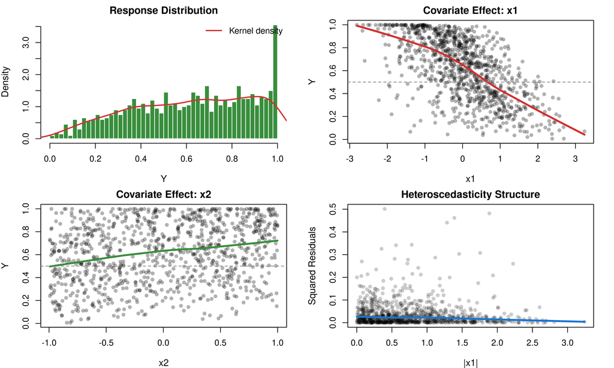

Distributional Characteristics - Scenario 1 (Well-Specified Beta)

```r
set.seed(123)
vis_data_s1 <- dgp_beta(1000, list(
  beta_mu = c(0.5, -0.8, 0.6),
  beta_phi = c(1.5, 0.4)
))

par(mfrow = c(2, 2), mar = c(4, 4, 2, 2))

# Response distribution
hist(vis_data_s1$y,
  breaks = 40, col = "#388E3C", border = "white",
  main = "Response Distribution", xlab = "Y", prob = TRUE,
  cex.main = 1.2, cex.lab = 1.1
)
lines(density(vis_data_s1$y), col = "#D32F2F", lwd = 2)
legend("topright", "Kernel density", col = "#D32F2F", lwd = 2, bty = "n")

# Effect of x1
plot(vis_data_s1$x1, vis_data_s1$y,
  pch = 16, col = rgb(0, 0, 0, 0.3),
  main = "Covariate Effect: x1", xlab = "x1", ylab = "Y",
  cex.main = 1.2, cex.lab = 1.1
)
lines(lowess(vis_data_s1$x1, vis_data_s1$y), col = "#D32F2F", lwd = 3)
abline(h = 0.5, lty = 2, col = "gray50")

# Effect of x2
plot(vis_data_s1$x2, vis_data_s1$y,
  pch = 16, col = rgb(0, 0, 0, 0.3),
  main = "Covariate Effect: x2", xlab = "x2", ylab = "Y",
  cex.main = 1.2, cex.lab = 1.1
)
lines(lowess(vis_data_s1$x2, vis_data_s1$y), col = "#388E3C", lwd = 3)
abline(h = 0.5, lty = 2, col = "gray50")

# Conditional variance
plot(abs(vis_data_s1$x1), (vis_data_s1$y - vis_data_s1$mu)^2,
  pch = 16, col = rgb(0, 0, 0, 0.2),
  main = "Heteroscedasticity Structure",
  xlab = "|x1|", ylab = "Squared Residuals",
  cex.main = 1.2, cex.lab = 1.1
)
lines(lowess(abs(vis_data_s1$x1), (vis_data_s1$y - vis_data_s1$mu)^2),
  col = "#1976D2", lwd = 3
)
```

```r
# mtext("Figure 1: Distributional Characteristics - Scenario 1 (Well-Specified Beta)",
#       side = 3, line = -2, outer = TRUE, font = 2, cex = 1.1)
```

### 4.2.2 Simulation Results

```r
results_s1 <- run_full_simulation(
  n_sim = 200,
  n = 300,
  dgp_fun = dgp_beta,
  params = list(
    beta_mu = c(0.5, -0.8, 0.6),
    beta_phi = c(1.5, 0.4)
  ),
  formula = y ~ x1 + x2 | x1
)
```

```
Note: Using Makevars in /home/jlopes/.R/Makevars
```

```
Note: Using Makevars in /home/jlopes/.R/Makevars
```

```
Note: Using Makevars in /home/jlopes/.R/Makevars
```

```r
comp_s1 <- make_comparison_table(results_s1)
```

### 4.2.3 Parameter Estimation Comparison

To assess coefficient recovery, we fit both Beta and Kumaraswamy models to a single representative dataset and compare parameter estimates. Table 1 presents the estimates, standard errors, and z-statistics.

```r
# Fit models to one dataset for coefficient comparison
set.seed(456)
data_coef_s1 <- dgp_beta(300, list(
  beta_mu = c(0.5, -0.8, 0.6),
  beta_phi = c(1.5, 0.4)
))

fit_beta_s1 <- betareg(y ~ x1 + x2 | x1, data = data_coef_s1)
fit_kw_s1 <- gkwreg(y ~ x1 + x2 | x1, data = data_coef_s1, family = "kw")

# Extract coefficients
coef_beta_s1 <- coef(fit_beta_s1)
se_beta_s1 <- sqrt(diag(vcov(fit_beta_s1)))

coef_kw_s1 <- coef(fit_kw_s1)
se_kw_s1 <- fit_kw_s1$se

# Build comparison table
coef_names <- names(coef_beta_s1)
true_values <- c(0.5, -0.8, 0.6, 1.5, 0.4)

coef_comparison_s1 <- data.frame(
  Parameter = coef_names,
  True_Value = true_values,
  Beta_Est = round(coef_beta_s1, 4),
  Beta_SE = round(se_beta_s1, 4),
  Beta_Z = round(coef_beta_s1 / se_beta_s1, 2),
  Kw_Est = round(coef_kw_s1, 4),
  Kw_SE = round(se_kw_s1, 4),
  Kw_Z = round(coef_kw_s1 / se_kw_s1, 2)
)

# Calculate differences
coef_comparison_s1$Bias_Beta <- round(coef_comparison_s1$Beta_Est - true_values, 4)
coef_comparison_s1$Bias_Kw <- round(coef_comparison_s1$Kw_Est - true_values, 4)
coef_comparison_s1$SE_Ratio <- round(coef_comparison_s1$Kw_SE / coef_comparison_s1$Beta_SE, 3)

knitr::kable(
  row.names = FALSE,
  coef_comparison_s1,
  caption = "Table 1: Parameter Estimates - Scenario 1 (Well-Specified Beta, n=300)",
  col.names = c(
    "Parameter", "True", "Est.", "SE", "z", "Est.", "SE", "z",
    "Bias", "Bias", "SE Ratio"
  ),
  align = c("l", rep("r", 10))
)
```

Table 1: Parameter Estimates - Scenario 1 (Well-Specified Beta, n=300)

| Parameter | True | Est. | SE | z | Est. | SE | z | Bias | Bias | SE Ratio |
| --- | --- | --- | --- | --- | --- | --- | --- | --- | --- | --- |
| (Intercept) | 0.5 | 0.5319 | 0.0541 | 9.84 | 0.9170 | 0.0703 | 13.04 | 0.0319 | 0.4170 | 1.299 |
| x1 | -0.8 | -0.8332 | 0.0555 | -15.02 | -0.2153 | 0.0605 | -3.56 | -0.0332 | 0.5847 | 1.090 |
| x2 | 0.6 | 0.6612 | 0.0853 | 7.75 | 0.4679 | 0.0740 | 6.32 | 0.0612 | -0.1321 | 0.868 |
| (phi)_(Intercept) | 1.5 | 1.5892 | 0.0784 | 20.27 | 0.4620 | 0.0841 | 5.49 | 0.0892 | -1.0380 | 1.073 |
| (phi)_x1 | 0.4 | 0.2245 | 0.0770 | 2.91 | 0.7872 | 0.0837 | 9.41 | -0.1755 | 0.3872 | 1.087 |

## 4.3 Scenario 2: Heavy-Tailed Data

**Data-generating process**: Exponentiated Kumaraswamy distribution with $λ = 1.82$ (exp(0.6)), inducing heavier tails than Beta can accommodate: - $\log(α) = 0.8 - 0.5x_1$ - $\log(β) = 0.3 + 0.4x_2$ - $x_1 \sim N(0,1)$, $x_2 \sim \text{Bernoulli}(0.5)$ - Sample size: $n = 300$

This scenario tests model robustness when the true distribution deviates from Beta assumptions.

```r
dgp_heavy_tails <- function(n, params) {
  x1 <- rnorm(n, 0, 1)
  x2 <- rbinom(n, 1, 0.5)

  eta_alpha <- params$beta_alpha[1] + params$beta_alpha[2] * x1
  eta_beta <- params$beta_beta[1] + params$beta_beta[2] * x2
  eta_lambda <- params$beta_lambda[1]

  alpha <- exp(eta_alpha)
  beta <- exp(eta_beta)
  lambda <- exp(eta_lambda)

  u <- runif(n)
  y <- (1 - (1 - u^(1 / beta))^(1 / alpha))^(1 / lambda)
  y <- pmax(pmin(y, 0.9999), 0.0001)

  data.frame(y = y, x1 = x1, x2 = factor(x2))
}
```